# Lab 02 - Take a sad plot and make it better

Group Members: Hannah, max, zety and user4

2022-10-08

### Load packages and data

```r
library(tidyverse)
```

```r
staff <- read_csv("data/instructional-staff.csv")
```

Team member 1 should pull to download updates and begins here.

### Exercise 1

Long data form of this data set will have 55 rows - one for each different observation. There are 11 different observations for each of the 5 faculty types.

Team member 1 should knit, stage & commit, and push all changes to GitHub.

Team member 2 should pull to download updates and begins here.

### Exercise 2

```r
staff_long <- staff %>%
  pivot_longer(
    cols = 2:12,
    names_to = "year",
   values_to = "percentage_hired"
    )
```

### Exercise 3

Previous guess is correct, dataframe has 55 rows and 3 columns, as shown below.

```r
dim(staff_long)
```

```
## [1] 55  3
```

Team member 2 should knit, stage & commit, and push all changes to GitHub.

Team member 3 should pull to download updates and begins here.

### Exercise 4

```
## geom_path: Each group consists of only one observation. Do you need to adjust
## the group aesthetic?
```

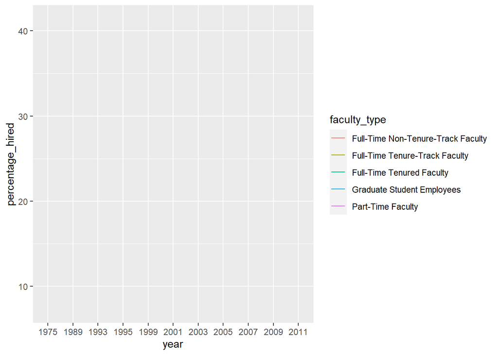

```r
staff_long %>%
  ggplot(aes(x = year, y = percentage_hired, color = faculty_type)) +
  geom_line()
```

The data is not plotted in the graph

### Exercise 5

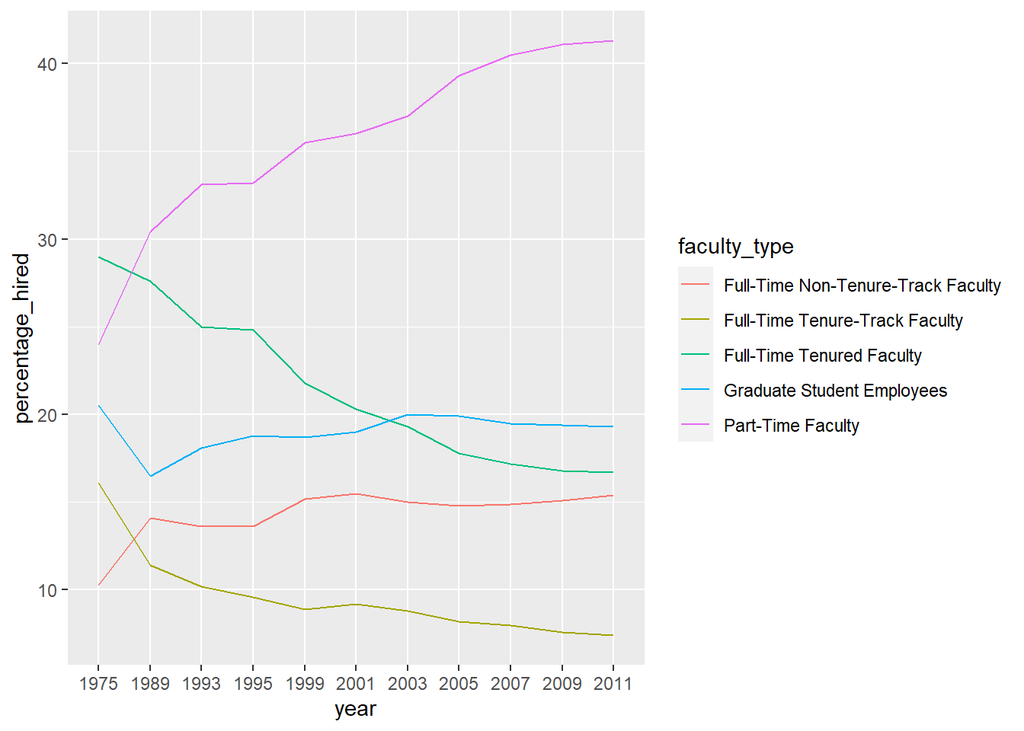

```r
staff_long %>%
  ggplot(aes(x = year, y = percentage_hired, color = faculty_type, group = faculty_type)) +
  geom_line()
```

Part time faculty percentage is increasing while the full time tenure percentage is decreasing.

Next team member should pull to download updates and continue from here.

### Exercise 6

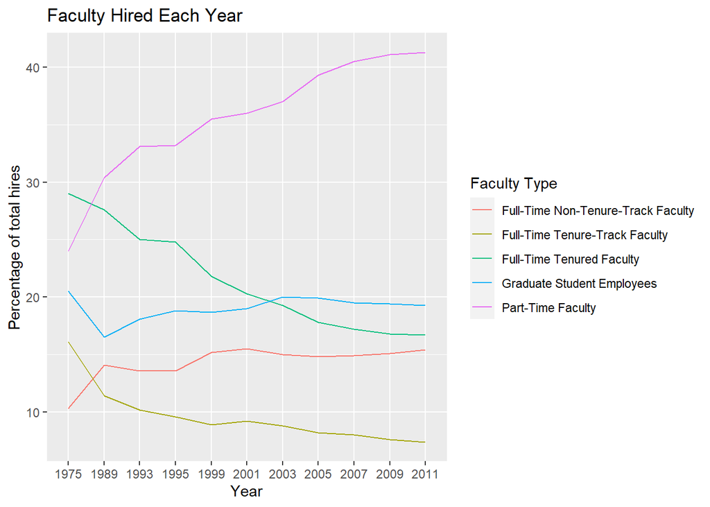

```r
staff_long %>%
  ggplot(aes(x = year, y = percentage_hired, color = faculty_type, group = faculty_type)) +
  geom_line() +
  labs(title = "Faculty Hired Each Year ",x = "Year", y = "Percentage of total hires", colour = "Faculty Type")
```

Current team member should knit, stage & commit, and push all changes to GitHub.

Next team member should pull to download updates and continue from here.

### Exercise 7

To plot proportion we need to add a new variable column. This column needs to contain the percentage values but just divided by 100. To do this, we could use a mutate function which will add an extra column with the newly calculated variable. We also need to filter the data set to just include part time staff.

### Exercise 8

The plot below now focuses on the main trend of the data set - the fact that the proportion of part time staff is increasing over time. It now only contains the important information so there is no longer any distraction from other lines or numbers.

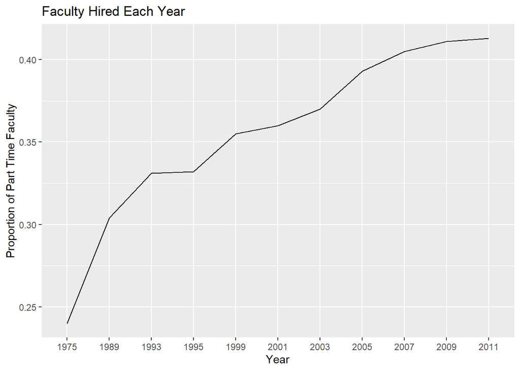

```r
staff_long %>%
  mutate(prop_hired = percentage_hired/100)%>%
  filter(faculty_type == "Part-Time Faculty") %>%

  ggplot(mapping = aes(
         x = year,
         y = prop_hired,
         group = faculty_type
         )) +
  geom_line()+
  labs(x = "Year",
       y = "Proportion of Part Time Faculty",
       title = "Faculty Hired Each Year",
       )
```

Current team member should knit, stage & commit, and push all changes to GitHub.

All team members should pull to download all updates.